# Frequentist Modeling Walkthrough with `lexdec` II: GLMER

Baichen Du

2026-05-07

```r
knitr::opts_chunk$set(echo = TRUE, warning = FALSE, message = FALSE)

library(languageR)
library(lme4)
library(dplyr)
library(tidyr)
library(ggplot2)
library(tibble)
library(DHARMa)
library(emmeans)
library(knitr)

set.seed(1234)
theme_set(theme_minimal(base_size = 12))
```

## 1 Overview

This is the second tutorial on frequentist modeling, see the [LMER modeling](https://baichen-du.github.io/lmer_modeling_walkthrough_lexdec) walkthrough for an introduction to this series.

This tutorial fits a generalized linear mixed-effects model with `glmer()` using the built-in `lexdec` data from the `languageR` package. The outcome is binary response accuracy: `1 = correct`, `0 = incorrect`. The factor of interest is `PrevType`, which records whether the previous trial was a word or nonword.

The workflow is:

1. Prepare tidy binary-outcome data.
2. Set the factor coding scheme.
3. Start with a maximally specified random-effects structure.
4. Fit the maximal model and check convergence and singular fit.
5. Fit a reduced random-effects model when the maximal model is problematic.
6. Use the reduced random-effects model as the working model.
7. Fit a reduced model that leaves out the fixed effect of interest.
8. Use `anova(reduced_model, full_model, test = "Chisq")` for the likelihood ratio test, which resembles `anova(model)` in LMER for factor significance checking.
9. Check GLMM diagnostics with `DHARMa`.
10. Interpret log-odds, odds ratios, and predicted probabilities.

## 2 Prepare the Data

### 2.1 Load data

```r
data("lexdec", package = "languageR")

dplyr::glimpse(lexdec)
```

```
## Rows: 1,659
## Columns: 28
## $ Subject        <fct> A1, A1, A1, A1, A1, A1, A1, A1, A1, A1, A1, A1, A1, A1,…
## $ RT             <dbl> 6.340359, 6.308098, 6.349139, 6.186209, 6.025866, 6.180…
## $ Trial          <int> 23, 27, 29, 30, 32, 33, 34, 38, 41, 42, 45, 46, 47, 48,…
## $ Sex            <fct> F, F, F, F, F, F, F, F, F, F, F, F, F, F, F, F, F, F, F…
## $ NativeLanguage <fct> English, English, English, English, English, English, E…
## $ Correct        <fct> correct, correct, correct, correct, correct, correct, c…
## $ PrevType       <fct> word, nonword, nonword, word, nonword, word, word, nonw…
## $ PrevCorrect    <fct> correct, correct, correct, correct, correct, correct, c…
## $ Word           <fct> owl, mole, cherry, pear, dog, blackberry, strawberry, s…
## $ Frequency      <dbl> 4.859812, 4.605170, 4.997212, 4.727388, 7.667626, 4.060…
## $ FamilySize     <dbl> 1.3862944, 1.0986123, 0.6931472, 0.0000000, 3.1354942, …
## $ SynsetCount    <dbl> 0.6931472, 1.9459101, 1.6094379, 1.0986123, 2.0794415, …
## $ Length         <int> 3, 4, 6, 4, 3, 10, 10, 8, 6, 6, 5, 8, 9, 5, 3, 4, 8, 6,…
## $ Class          <fct> animal, animal, plant, plant, animal, plant, plant, ani…
## $ FreqSingular   <int> 54, 69, 83, 44, 1233, 26, 50, 63, 11, 24, 104, 28, 7, 2…
## $ FreqPlural     <int> 74, 30, 49, 68, 828, 31, 65, 47, 9, 42, 95, 28, 4, 45, …
## $ DerivEntropy   <dbl> 0.7912, 0.6968, 0.4754, 0.0000, 1.2129, 0.3492, 0.0000,…
## $ Complex        <fct> simplex, simplex, simplex, simplex, simplex, complex, c…
## $ rInfl          <dbl> -0.31015493, 0.81450804, 0.51879379, -0.42744401, 0.397…
## $ meanRT         <dbl> 6.3582, 6.4150, 6.3426, 6.3353, 6.2956, 6.3959, 6.3475,…
## $ SubjFreq       <dbl> 3.12, 2.40, 3.88, 4.52, 6.04, 3.28, 5.04, 2.80, 3.12, 3…
## $ meanSize       <dbl> 3.4758, 2.9999, 1.6278, 1.9908, 4.6429, 1.5831, 1.8922,…
## $ meanWeight     <dbl> 3.1806, 2.6112, 1.2081, 1.6114, 4.5167, 1.1365, 1.4951,…
## $ BNCw           <dbl> 12.057065, 5.738806, 5.716520, 2.050370, 74.838494, 1.2…
## $ BNCc           <dbl> 0.000000, 4.062251, 3.249801, 1.462410, 50.859385, 0.16…
## $ BNCd           <dbl> 6.175602, 2.850278, 12.588727, 7.363218, 241.561040, 1.…
## $ BNCcRatio      <dbl> 0.000000, 0.707856, 0.568493, 0.713242, 0.679589, 0.127…
## $ BNCdRatio      <dbl> 0.512198, 0.496667, 2.202166, 3.591166, 3.227765, 0.934…
```

### 2.2 Data cleaning, data type coercing, etc.

```r
lexdec_glmer <- lexdec %>%
  filter(
    !is.na(Correct),
    !is.na(PrevType),
    !is.na(Trial),
    !is.na(Frequency),
    !is.na(Length),
    !is.na(Subject),
    !is.na(Word)
  ) %>%
  mutate(
    Subject = factor(Subject),
    Word = factor(Word),
    Correct = factor(Correct, levels = c("incorrect", "correct")),
    Correct_binary = if_else(Correct == "correct", 1L, 0L),
    PrevType = factor(PrevType, levels = c("nonword", "word")),
    Trial_z = as.numeric(scale(Trial)),
    Frequency_z = as.numeric(scale(Frequency)),
    Length_z = as.numeric(scale(Length))
  ) %>%
  droplevels()

lexdec_glmer
```

|  | Subject | RT | Trial | Sex | NativeLanguage | Correct | PrevType | PrevCorrect | Word | Frequency | FamilySize | SynsetCount | Length | Class | FreqSingular | FreqPlural | DerivEntropy | Complex | rInfl | meanRT | SubjFreq | meanSize | meanWeight | BNCw | BNCc | BNCd | BNCcRatio | BNCdRatio | Correct_binary | … |
| --- | --- | --- | --- | --- | --- | --- | --- | --- | --- | --- | --- | --- | --- | --- | --- | --- | --- | --- | --- | --- | --- | --- | --- | --- | --- | --- | --- | --- | --- | --- |
| 1 | A1 | 6.340359 | 23 | F | English | correct | word | correct | owl | 4.859812 | 1.3862944 | 0.6931472 | 3 | animal | 54 | 74 | 0.7912 | simplex | -0.31015493 | 6.3582 | 3.12 | 3.4758 | 3.1806 | 12.057065 | 0.000000 | 6.175602 | 0.000000 | 0.512198 | 1 | … |
| 2 | A1 | 6.308098 | 27 | F | English | correct | nonword | correct | mole | 4.605170 | 1.0986123 | 1.9459101 | 4 | animal | 69 | 30 | 0.6968 | simplex | 0.81450804 | 6.4150 | 2.40 | 2.9999 | 2.6112 | 5.738806 | 4.062251 | 2.850278 | 0.707856 | 0.496667 | 1 | … |
| 3 | A1 | 6.349139 | 29 | F | English | correct | nonword | correct | cherry | 4.997212 | 0.6931472 | 1.6094379 | 6 | plant | 83 | 49 | 0.4754 | simplex | 0.51879379 | 6.3426 | 3.88 | 1.6278 | 1.2081 | 5.716520 | 3.249801 | 12.588727 | 0.568493 | 2.202166 | 1 | … |
| 4 | A1 | 6.186209 | 30 | F | English | correct | word | correct | pear | 4.727388 | 0.0000000 | 1.0986123 | 4 | plant | 44 | 68 | 0.0000 | simplex | -0.42744401 | 6.3353 | 4.52 | 1.9908 | 1.6114 | 2.050370 | 1.462410 | 7.363218 | 0.713242 | 3.591166 | 1 | … |
| 5 | A1 | 6.025866 | 32 | F | English | correct | nonword | correct | dog | 7.667626 | 3.1354942 | 2.0794415 | 3 | animal | 1233 | 828 | 1.2129 | simplex | 0.39779605 | 6.2956 | 6.04 | 4.6429 | 4.5167 | 74.838494 | 50.859385 | 241.561040 | 0.679589 | 3.227765 | 1 | … |
| 6 | A1 | 6.180017 | 33 | F | English | correct | word | correct | blackberry | 4.060443 | 0.6931472 | 1.3862944 | 10 | plant | 26 | 31 | 0.3492 | complex | -0.16989904 | 6.3959 | 3.28 | 1.5831 | 1.1365 | 1.270338 | 0.162490 | 1.187616 | 0.127911 | 0.934882 | 1 | … |
| 7 | A1 | 6.035481 | 34 | F | English | correct | word | correct | strawberry | 4.753590 | 0.0000000 | 1.3862944 | 10 | plant | 50 | 65 | 0.0000 | complex | -0.25782911 | 6.3475 | 5.04 | 1.8922 | 1.4951 | 2.919548 | 0.649960 | 18.526805 | 0.222624 | 6.345778 | 1 | … |
| 8 | A1 | 6.263398 | 38 | F | English | correct | nonword | correct | squirrel | 4.709530 | 0.0000000 | 1.0986123 | 8 | animal | 63 | 47 | 0.0000 | simplex | 0.28768207 | 6.4491 | 2.80 | 3.7114 | 3.4178 | 2.406956 | 0.812450 | 1.425139 | 0.337543 | 0.592092 | 1 | … |
| 9 | A1 | 6.459904 | 41 | F | English | correct | nonword | correct | radish | 3.044522 | 0.6931472 | 1.3862944 | 6 | plant | 11 | 9 | 0.9403 | simplex | 0.18232156 | 6.4133 | 3.12 | 1.3226 | 0.8244 | 1.961223 | 0.000000 | 0.000000 | 0.000000 | 0.000000 | 1 | … |
| 10 | A1 | 6.184149 | 42 | F | English | correct | word | correct | almond | 4.204693 | 0.0000000 | 1.0986123 | 6 | plant | 24 | 42 | 0.0000 | simplex | -0.54232429 | 6.3908 | 3.72 | 1.8912 | 1.4860 | 3.075555 | 0.162490 | 1.425139 | 0.052833 | 0.463376 | 1 | … |

[output cut: 1649 more lines]

## 3 Set the coding scheme

The predictor of interest, `PrevType`, is sum coded. With a two-level factor, the coefficient is a deviation from the grand mean on the log-odds scale. Estimated marginal means are usually clearer for interpretation.

```r
contrasts(lexdec_glmer$PrevType) <- contr.sum(2)

contrasts(lexdec_glmer$PrevType)
```

```
##         [,1]
## nonword    1
## word      -1
```

## 4 Summary statistics

```r
lexdec_glmer %>%
  summarise(
    n_observations = n(),
    n_subjects = n_distinct(Subject),
    n_words = n_distinct(Word),
    proportion_correct = mean(Correct_binary)
  )
```

| n_observations | n_subjects | n_words | proportion_correct |
| --- | --- | --- | --- |
| 1659 | 21 | 79 | 0.9608198 |

```r
lexdec_glmer %>%
  count(Correct)
```

| Correct | n |
| --- | --- |
| incorrect | 65 |
| correct | 1594 |

```r
lexdec_glmer %>%
  count(PrevType, Correct)
```

| PrevType | Correct | n |
| --- | --- | --- |
| nonword | incorrect | 30 |
| nonword | correct | 825 |
| word | incorrect | 35 |
| word | correct | 769 |

### 4.1 Plotting data patterns

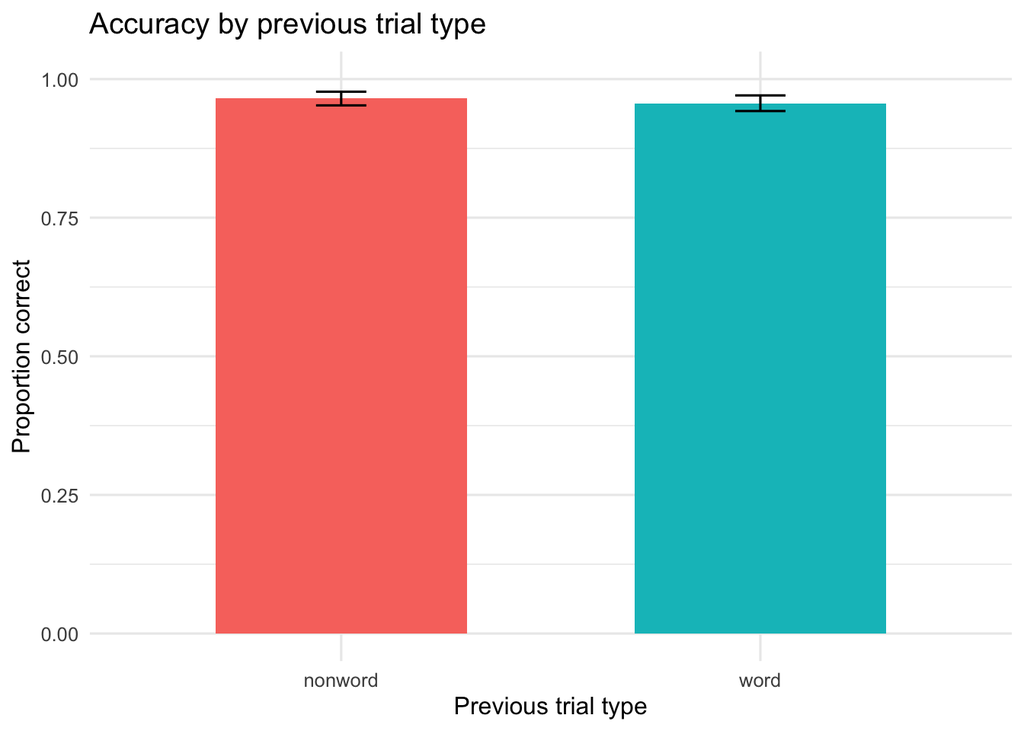

```r
accuracy_by_prevtype <- lexdec_glmer %>%
  group_by(PrevType) %>%
  summarise(
    n = n(),
    proportion_correct = mean(Correct_binary),
    se = sqrt(proportion_correct * (1 - proportion_correct) / n),
    lower = pmax(0, proportion_correct - 1.96 * se),
    upper = pmin(1, proportion_correct + 1.96 * se),
    .groups = "drop"
  )

ggplot(accuracy_by_prevtype, aes(x = PrevType, y = proportion_correct, fill = PrevType)) +
  geom_col(width = 0.6) +
  geom_errorbar(aes(ymin = lower, ymax = upper), width = 0.12) +
  scale_y_continuous(limits = c(0, 1)) +
  labs(
    x = "Previous trial type",
    y = "Proportion correct",
    title = "Accuracy by previous trial type"
  ) +
  guides(fill = "none")
```

## 5 Start With the Maximal Random Structure

The maximal structure includes random intercepts for subjects and words. It also includes random slopes for predictors that vary within each grouping factor.

For subjects, `PrevType`, `Trial_z`, `Frequency_z`, and `Length_z` vary across trials. For words, `Frequency_z` and `Length_z` are item-level properties, so they do not vary within a word and are not used as word-level random slopes.

If the maximal model does not converge or is singular, simplify the random structure. In a real analysis, this reduction should be theoretically motivated: remove the least important or least stable random slopes first, while keeping the fixed-effects structure aligned with the research question.

## 6 Fit the Maximal Model

```r
glmer_control <- lme4::glmerControl(
  optimizer = "bobyqa",
  optCtrl = list(maxfun = 200000)
)

glmer_maximal <- lme4::glmer(
  Correct_binary ~ PrevType + Trial_z + Frequency_z + Length_z +
    (1 + PrevType + Trial_z + Frequency_z + Length_z | Subject) +
    (1 + PrevType + Trial_z | Word),
  data = lexdec_glmer,
  family = binomial(link = "logit"),
  control = glmer_control
)
```

## 7 Check model convergence and singular fit

```r
cat("Model singular fit: ", lme4::isSingular(glmer_maximal), "\n", sep = "")
```

```
## Model singular fit: TRUE
```

```r
cat(
  "Model failed to converge: ",
  length(glmer_maximal@optinfo$conv$lme4$messages) > 0,
  "\n",
  sep = ""
)
```

```
## Model failed to converge: TRUE
```

## 8 Fit a Reduced Random-Effects Model

For the rest of this walkthrough, I pretend that the maximal model above is too complex because it has a convergence warning, a singular fit, or both. The next step is to fit a simpler random-effects structure.

Here I simplify to random intercepts for subjects and words. This is a common endpoint when the random-slope structure is too ambitious for a binary outcome, especially when one outcome level is rare.

```r
glmer_reduced_random <- lme4::glmer(
  Correct_binary ~ PrevType + Trial_z + Frequency_z + Length_z +
    (1 | Subject) +
    (1 | Word),
  data = lexdec_glmer,
  family = binomial(link = "logit"),
  control = glmer_control
)
```

## 9 Check convergence and fit for the reduced model

```r
cat("Model singular fit: ", lme4::isSingular(glmer_reduced_random), "\n", sep = "")
```

```
## Model singular fit: FALSE
```

```r
cat(
  "Model failed to converge: ",
  length(glmer_reduced_random@optinfo$conv$lme4$messages) > 0,
  "\n",
  sep = ""
)
```

```
## Model failed to converge: FALSE
```

For this walkthrough, I treat the reduced random-effects model as the final working full model. In a real analysis, if this reduced model still had convergence or singularity problems, I would continue simplifying the random-effects structure and document each step.

```r
glmer_fit <- glmer_reduced_random
selected_glmer_name <- "reduced model: subject and word random intercepts"

selected_glmer_name
```

```
## [1] "reduced model: subject and word random intercepts"
```

```r
formula(glmer_fit)
```

```
## Correct_binary ~ PrevType + Trial_z + Frequency_z + Length_z +
##     (1 | Subject) + (1 | Word)
```

## 10 Fit the Reduced Main-Effect Model

For the GLMM, test the factor of interest by comparing the full model against a reduced model that leaves out the fixed effect of `PrevType`. The reduced model keeps the same random-effects structure as the working full model, so the likelihood-ratio test targets the fixed effect.

```r
glmer_without_prevtype <- lme4::glmer(
  Correct_binary ~ Trial_z + Frequency_z + Length_z +
    (1 | Subject) +
    (1 | Word),
  data = lexdec_glmer,
  family = binomial(link = "logit"),
  control = glmer_control
)

summary(glmer_without_prevtype)
```

```
## Generalized linear mixed model fit by maximum likelihood (Laplace
##   Approximation) [glmerMod]
##  Family: binomial  ( logit )
## Formula: Correct_binary ~ Trial_z + Frequency_z + Length_z + (1 | Subject) +
##     (1 | Word)
##    Data: lexdec_glmer
## Control: glmer_control
##
##       AIC       BIC    logLik -2*log(L)  df.resid
##     500.6     533.1    -244.3     488.6      1653
##
## Scaled residuals:
##     Min      1Q  Median      3Q     Max
## -8.6078  0.0860  0.1247  0.1852  0.9657
##
## Random effects:
##  Groups  Name        Variance Std.Dev.
##  Word    (Intercept) 1.0139   1.007
##  Subject (Intercept) 0.7604   0.872
## Number of obs: 1659, groups:  Word, 79; Subject, 21
##
## Fixed effects:
##              Estimate Std. Error z value Pr(>|z|)
## (Intercept)  4.174183   0.354513  11.774  < 2e-16 ***
## Trial_z      0.003881   0.136700   0.028  0.97735
## Frequency_z  0.699130   0.215421   3.245  0.00117 **
## Length_z    -0.036793   0.209517  -0.176  0.86060
## ---
## Signif. codes:  0 '***' 0.001 '**' 0.01 '*' 0.05 '.' 0.1 ' ' 1
##
## Correlation of Fixed Effects:
##             (Intr) Tril_z Frqnc_
## Trial_z     -0.010
## Frequency_z  0.214  0.001
## Length_z    -0.017 -0.023  0.407
```

## 11 Check the sigificance of the variable of interest

```r
glmer_lrt <- anova(
  glmer_without_prevtype,
  glmer_fit,
  test = "Chisq"
)

glmer_lrt
```

|  | npar | AIC | BIC | logLik | -2*log(L) | Chisq | Df | Pr(>Chisq) |
| --- | --- | --- | --- | --- | --- | --- | --- | --- |
| glmer_without_prevtype | 6 | 500.6224 | 533.1063 | -244.3112 | 488.6224 | NA | NA | NA |
| glmer_fit | 7 | 501.8248 | 539.7226 | -243.9124 | 487.8248 | 0.7976097 | 1 | 0.371809 |

## 12 Check GLMM Diagnostics With DHARMa

For GLMMs, residual diagnostics are not the same as ordinary linear-model residual checks. `DHARMa` simulates scaled residuals from the fitted model and tests whether they behave as expected under the model.

This does not mean that you cannot use the `performance` package to do model checking. It is just that the results are less intuitive and less transparent to interpret whether the model actually meets the assumptions or not.

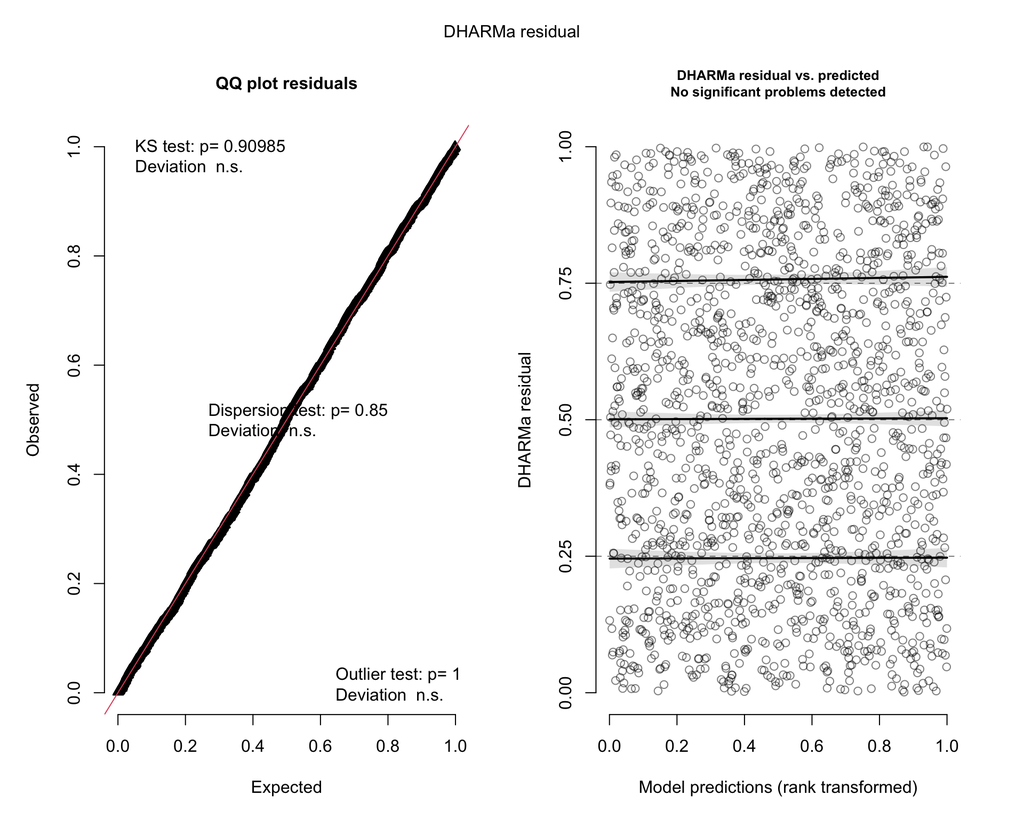

```r
set.seed(1234)

glmer_dharma_residuals <- DHARMa::simulateResiduals(
  fittedModel = glmer_fit,
  n = 1000
)

plot(glmer_dharma_residuals)
```

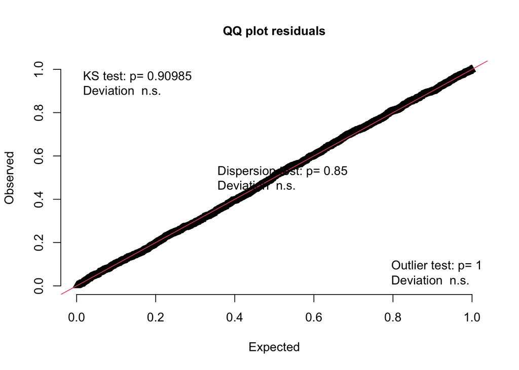

```
##
##  Asymptotic one-sample Kolmogorov-Smirnov test
##
## data:  simulationOutput$scaledResiduals
## D = 0.013807, p-value = 0.9098
## alternative hypothesis: two-sided
```

```r
DHARMa::testUniformity(glmer_dharma_residuals)
```

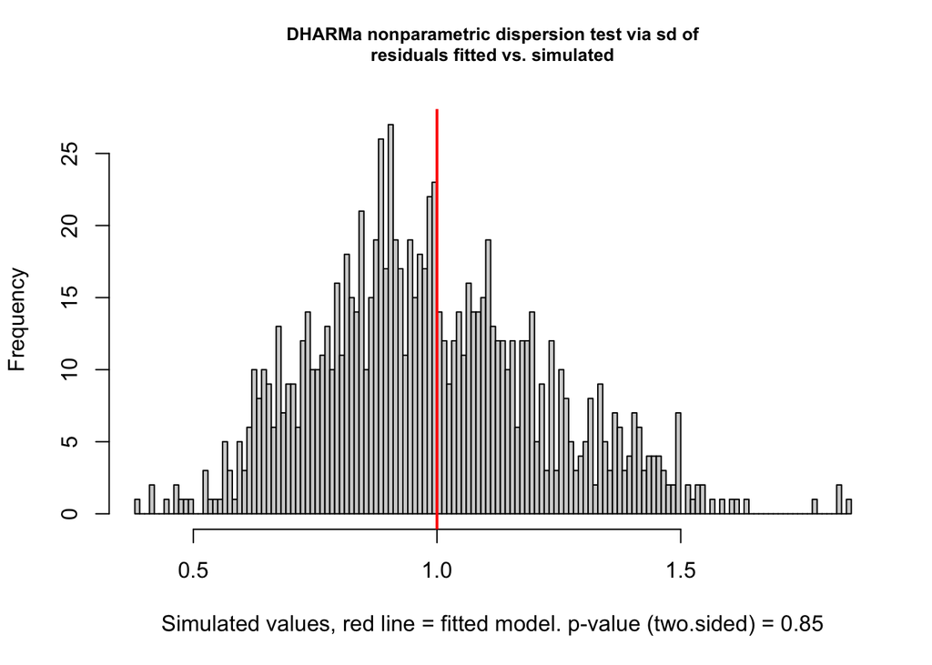

```
##
##  DHARMa nonparametric dispersion test via sd of residuals fitted vs.
##  simulated
##
## data:  simulationOutput
## dispersion = 1.016, p-value = 0.85
## alternative hypothesis: two.sided
```

```r
DHARMa::testDispersion(glmer_dharma_residuals)
```

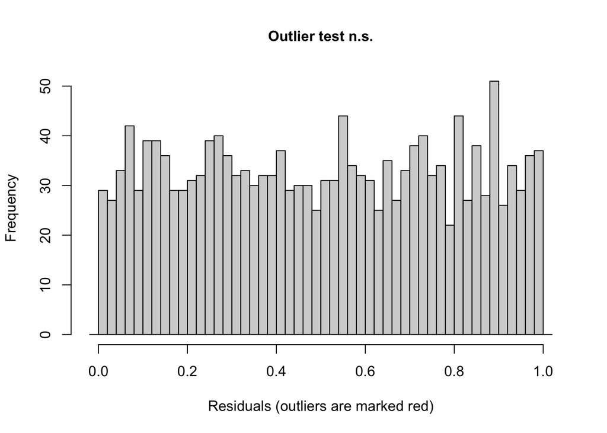

```
##
##  DHARMa outlier test based on exact binomial test with approximate
##  expectations
##
## data:  glmer_dharma_residuals
## outliers at both margin(s) = 3, observations = 1659, p-value = 1
## alternative hypothesis: true probability of success is not equal to 0.001998002
## 95 percent confidence interval:
##  0.0003730741 0.0052754946
## sample estimates:
## frequency of outliers (expected: 0.001998001998002 )
##                                          0.001808318
```

```r
DHARMa::testOutliers(glmer_dharma_residuals)
```

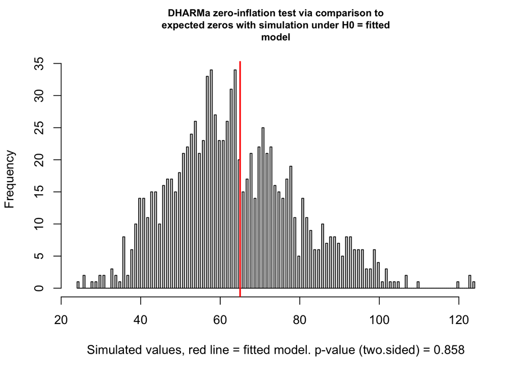

```
##
##  DHARMa zero-inflation test via comparison to expected zeros with
##  simulation under H0 = fitted model
##
## data:  simulationOutput
## ratioObsSim = 1.0182, p-value = 0.858
## alternative hypothesis: two.sided
```

```r
DHARMa::testZeroInflation(glmer_dharma_residuals)
```

If these checks look poor, common next steps include a different predictor structure, nonlinear terms, checking separation or rare-event behavior, adding missing grouping structure, or using a different model family.

## 13 Interpret the Model

The GLMM coefficients are on the log-odds scale. Exponentiating them gives odds ratios. Estimated marginal means with `type = "response"` give predicted probabilities, which are often easier to explain.

```r
glmer_fixed_effects <- coef(summary(glmer_fit)) %>%
  as.data.frame() %>%
  tibble::rownames_to_column("term") %>%
  as_tibble()

glmer_fixed_effects %>%
  knitr::kable(digits = 3)
```

| term | Estimate | Std. Error | z value | Pr(>\|z\|) |
| --- | --- | --- | --- | --- |
| (Intercept) | 4.184 | 0.358 | 11.702 | 0.000 |
| PrevType1 | 0.124 | 0.139 | 0.891 | 0.373 |
| Trial_z | 0.007 | 0.137 | 0.053 | 0.958 |
| Frequency_z | 0.700 | 0.215 | 3.254 | 0.001 |
| Length_z | -0.034 | 0.209 | -0.162 | 0.871 |

```r
glmer_wald_ci <- confint(
  glmer_fit,
  parm = "beta_",
  method = "Wald"
)

glmer_odds_ratios <- tibble(
  term = names(lme4::fixef(glmer_fit)),
  log_odds = unname(lme4::fixef(glmer_fit)),
  conf_low_log_odds = glmer_wald_ci[, 1],
  conf_high_log_odds = glmer_wald_ci[, 2]
) %>%
  mutate(
    odds_ratio = exp(log_odds),
    conf_low_odds_ratio = exp(conf_low_log_odds),
    conf_high_odds_ratio = exp(conf_high_log_odds)
  )

glmer_odds_ratios %>%
  knitr::kable(digits = 3)
```

| term | log_odds | conf_low_log_odds | conf_high_log_odds | odds_ratio | conf_low_odds_ratio | conf_high_odds_ratio |
| --- | --- | --- | --- | --- | --- | --- |
| (Intercept) | 4.184 | 3.483 | 4.885 | 65.618 | 32.560 | 132.241 |
| PrevType1 | 0.124 | -0.149 | 0.397 | 1.132 | 0.862 | 1.487 |
| Trial_z | 0.007 | -0.261 | 0.275 | 1.007 | 0.770 | 1.317 |
| Frequency_z | 0.700 | 0.278 | 1.121 | 2.013 | 1.321 | 3.068 |
| Length_z | -0.034 | -0.444 | 0.376 | 0.967 | 0.642 | 1.456 |

```r
glmer_prevtype_logit <- emmeans::emmeans(glmer_fit, ~ PrevType)
glmer_prevtype_probability <- emmeans::emmeans(
  glmer_fit,
  ~ PrevType,
  type = "response"
)
glmer_prevtype_contrast <- pairs(glmer_prevtype_probability, type = "response")

glmer_prevtype_logit
```

```
##  PrevType emmean    SE  df asymp.LCL asymp.UCL
##  nonword    4.31 0.391 Inf      3.54      5.08
##  word       4.06 0.376 Inf      3.32      4.80
##
## Results are given on the logit (not the response) scale.
## Confidence level used: 0.95
```

```r
glmer_prevtype_probability
```

```
##  PrevType  prob      SE  df asymp.LCL asymp.UCL
##  nonword  0.987 0.00513 Inf     0.972     0.994
##  word     0.983 0.00626 Inf     0.965     0.992
##
## Confidence level used: 0.95
## Intervals are back-transformed from the logit scale
```

```r
glmer_prevtype_contrast
```

```
##  contrast       odds.ratio    SE  df null z.ratio p.value
##  nonword / word       1.28 0.357 Inf    1   0.891  0.3728
##
## Tests are performed on the log odds ratio scale
```

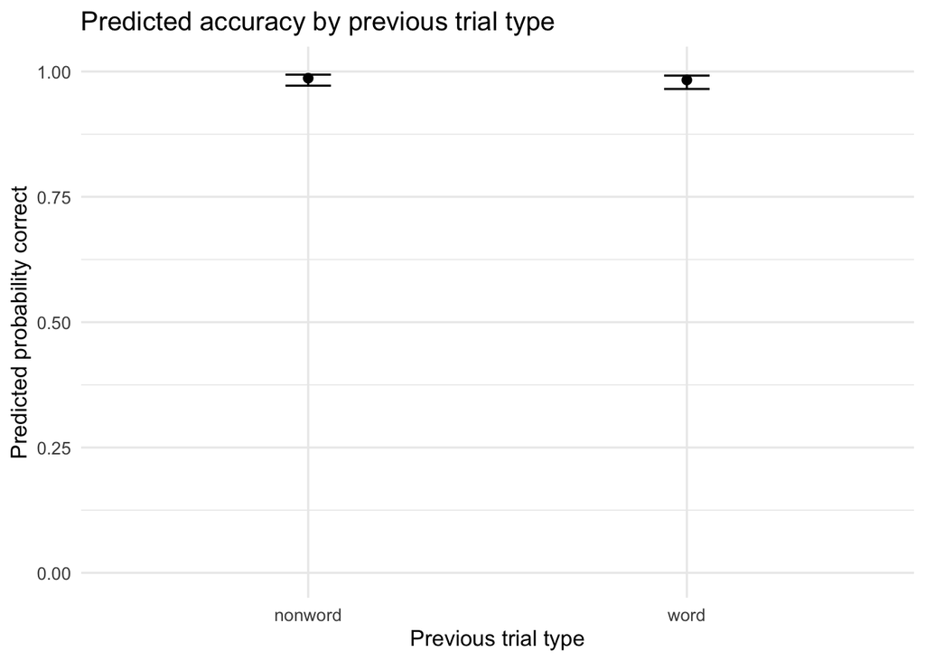

```r
glmer_prevtype_probability_df <- as.data.frame(glmer_prevtype_probability)

ggplot(glmer_prevtype_probability_df, aes(x = PrevType, y = prob)) +
  geom_point(size = 2) +
  geom_errorbar(aes(ymin = asymp.LCL, ymax = asymp.UCL), width = 0.12) +
  scale_y_continuous(limits = c(0, 1)) +
  labs(
    x = "Previous trial type",
    y = "Predicted probability correct",
    title = "Predicted accuracy by previous trial type"
  )
```

## 14 Example Reporting Language

> We fit a logistic mixed-effects model predicting response accuracy from previous trial type, trial order, word frequency, and word length. Factors were sum coded. I started with the maximal theoretically relevant random-effects structure and checked whether it had convergence warnings or a singular fit. To demonstrate the usual reduction workflow, I then fit a reduced random-effects structure and used it as the working full model. The working random-effects structure was reduced model: subject and word random intercepts. The fixed effect of previous trial type was evaluated by comparing the full model to a reduced model without that fixed effect using a likelihood-ratio test. GLMM diagnostics were checked with simulated residuals from `DHARMa`. Coefficients are reported on the log-odds scale, odds ratios are provided for fixed effects, and the effect of previous trial type is interpreted with predicted probabilities.